# Lab 10 _ Matrices Complejas

Cony

2025-10-03

Hecho con gusto por Carla Carolina Pérez Hernández (UAEH) Adaptado por Alumna Maria Concepcion Garcia Pérez

T1_04_REDES COMPLEJAS(1) - Visión de redes complejas - parte 1

Objetivo: Estimar el Maximum Spanning Tree -árbol de expansión máxima- (asegurar una visión clara del espacio-producto) Red troncal: Estructura general de la red: vamos a poder v. redes complejas

Regla 1: mantener n-1 conexiones como máximo Regla 2: Quitar las conexiones con el peso más bajo, nos vamos quedar con las del peso máximo (menos conexiones) Regla 3: No crear nodos aislados

En este ejercicio vamos a: 1. Usar un matriz hipotetica de datos 2. Graficar sus próximos adyacentes

practica 3: Visión clara del espacio-producto: CASO HIPOTÉTICO

1)la visualización del espacio - producto sea una red conectada: evitar islas de productos aislados. 2)PROBLEMA: tratar de visualizar demasiados enlaces puede crear una complejidad visual innecesaria donde se obstruirán las conexiones más relevantes. calculamos el árbol de expansión máxima (MST) de la matriz de proximidad. MST es el conjunto de enlaces que conecta todos los nodos de la red utilizando un número mínimo de conexiones y la suma máxima posible de proximidades. Calculamos el MST usando el algoritmo de Kruskal: Básicamente, el algoritmo clasifica los valores de la matriz de proximidad en orden descendente y luego incluye enlaces en el MST si y solo si conectan un producto aislado. Por definición, el MST incluye todos los productos, pero el número de enlaces es el mínimo posible. Después de seleccionar los enlaces utilizando los criterios mencionados anteriormente, construimos una visualización utilizando un algoritmo de diseño dirigido por la fuerza.

crear una matriz aleatoria de 200*200

```r
M <- matrix(runif(200*200,min=0, max=100), ncol=200)
diag(M)<-1
head(M[,1:16])
```

```
##          [,1]      [,2]     [,3]     [,4]      [,5]      [,6]     [,7]
## [1,]  1.00000 23.447363 78.50626 28.05101 95.958296  9.704884 18.70863
## [2,] 79.28849  1.000000 92.00730 57.19117 51.617533 28.231764 57.18226
## [3,] 37.46815 99.240848  1.00000 30.09246 66.989637 42.536344 18.24315
## [4,] 38.56896  1.641467 40.49086  1.00000 54.982948  9.128791 88.01390
## [5,] 98.40962 38.799012 22.80708 10.96126  1.000000 96.724383 22.51088
## [6,] 22.36404 84.729566 66.60445 50.79334  2.558197  1.000000 10.82578
##           [,8]     [,9]     [,10]    [,11]     [,12]    [,13]    [,14]
## [1,]  8.217396 94.63285 72.132149 26.97820 67.155230 70.92653 39.74149
## [2,]  7.289394 61.91166  8.499584 48.63980 85.830960 81.75393 79.63140
## [3,] 17.917352 51.82698 72.719348 34.42148  3.473521 86.77361 29.12783
## [4,] 67.223872 75.48169 13.381568 17.08919 48.846768 13.35553 97.61676
## [5,] 45.172014 62.53838 61.690698 14.87378 90.832474 62.74231 24.59286
## [6,] 49.542363 69.20849 27.031100 10.49751 85.795599 66.18461 99.82372
##          [,15]    [,16]
## [1,] 63.846039 71.27768
## [2,] 81.613115 79.63800
## [3,] 88.438255 42.74248
## [4,]  6.848449 70.34558
## [5,] 57.139862 69.73290
## [6,] 61.438506  7.44515
```

```r
dim(M)
```

```
## [1] 200 200
```

grafica la matriz

```r
library (igraph)
g <- graph.adjacency(M, mode="undirected", weighted=TRUE)
g
```

```
## IGRAPH 5acb13e U-W- 200 20100 --
## + attr: weight (e/n)
## + edges from 5acb13e:
##  [1] 1-- 1 1-- 2 1-- 3 1-- 4 1-- 5 1-- 6 1-- 7 1-- 8 1-- 9 1--10 1--11 1--12
## [13] 1--13 1--14 1--15 1--16 1--17 1--18 1--19 1--20 1--21 1--22 1--23 1--24
## [25] 1--25 1--26 1--27 1--28 1--29 1--30 1--31 1--32 1--33 1--34 1--35 1--36
## [37] 1--37 1--38 1--39 1--40 1--41 1--42 1--43 1--44 1--45 1--46 1--47 1--48
## [49] 1--49 1--50 1--51 1--52 1--53 1--54 1--55 1--56 1--57 1--58 1--59 1--60
## [61] 1--61 1--62 1--63 1--64 1--65 1--66 1--67 1--68 1--69 1--70 1--71 1--72
## [73] 1--73 1--74 1--75 1--76 1--77 1--78 1--79 1--80 1--81 1--82 1--83 1--84
## [85] 1--85 1--86 1--87 1--88 1--89 1--90 1--91 1--92 1--93 1--94 1--95 1--96
## + ... omitted several edges
```

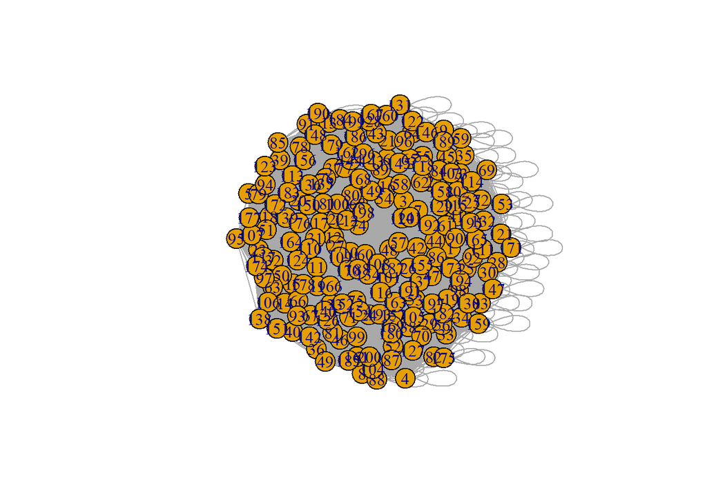

```r
plot(g)
```

Transforma la matriz en en NEGATIVA y para identificar los máximos

```r
M<- -M
head(M[1:6])
```

```
## [1]  -1.00000 -79.28849 -37.46815 -38.56896 -98.40962 -22.36404
```

grafica nueva con matriz negativa, ver el espacio-producto, tecnológico

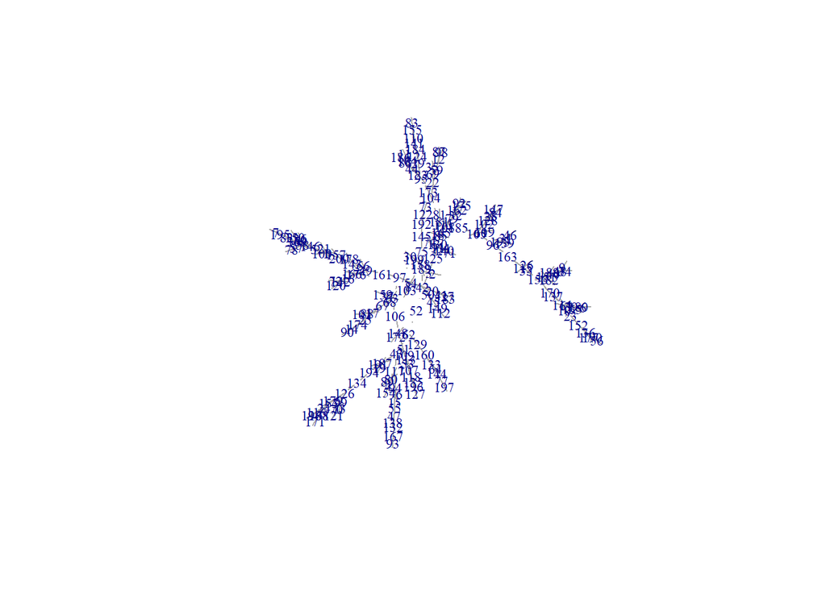

```r
g <- graph.adjacency(M, mode="undirected", weighted=TRUE)
MST <- minimum.spanning.tree(g)
plot(MST, vertex.shape="none", vertex.label.cex=0.7)
```

matriz de adyacencias (nuevo relacionamiento)

```r
A<- get.adjacency(MST,sparse = F)
```

ver las aristas que hay entre los nodos

```r
head(A)
```

```
##      [,1] [,2] [,3] [,4] [,5] [,6] [,7] [,8] [,9] [,10] [,11] [,12] [,13] [,14]
## [1,]    0    0    0    0    1    0    0    0    0     0     0     0     0     0
## [2,]    0    0    1    0    0    0    0    0    0     0     0     0     0     0
## [3,]    0    1    0    0    0    0    0    0    0     0     0     0     0     0
## [4,]    0    0    0    0    0    0    0    0    0     0     0     0     0     0
## [5,]    1    0    0    0    0    0    0    0    0     0     0     0     0     0
## [6,]    0    0    0    0    0    0    0    0    0     0     0     0     0     0
##      [,15] [,16] [,17] [,18] [,19] [,20] [,21] [,22] [,23] [,24] [,25] [,26]
## [1,]     0     0     0     0     0     0     1     0     0     0     0     0
## [2,]     0     0     0     0     0     0     0     0     0     0     0     0
## [3,]     0     0     0     0     0     0     0     0     0     0     0     0
## [4,]     0     0     0     0     0     0     0     0     0     0     0     0
## [5,]     0     0     0     0     0     0     0     0     0     0     0     0
## [6,]     0     0     0     0     0     0     0     0     0     0     0     0
##      [,27] [,28] [,29] [,30] [,31] [,32] [,33] [,34] [,35] [,36] [,37] [,38]
```

[output cut: 118 more lines]

VER LAS ARISTAS(PESOS)

```r
write.graph(MST, file="g.gml", format="gml")
```

nodos n-1 exportar resultados para cytoscape o gephi

```r
write.csv(A,file="Adyacences.csv")
```